# How to Win in Basketball: Analyzing 2024 Men’s D1 Collegiate Basketball Season

Eric Simmons

2024-11-10

# INTRODUCTION

I was interested in comparing the statistics of all of the other Division I Men’s basketball programs for the 2024 season. My dataset consists of the 362 college teams, with variables including Conference, Games Played, Games Won, Free Throw Rate, Three Point Shooting Percentage, and many others.

I decided to ask several questions that would help illustrate the usage of R, such as the ways in which the variables interacted and particularly contributed to the successes or failures of individual teams. This information could later be applicable to what factors of a basketball season will lead to greater success or failure, in general.

Each of these questions and my subsequent answers using R demonstrates my ability to analyze data using data visualization, data wrangling, & simple regression analysis. The results have been visualized through my R code and the graphs that I have produced.

# NECESSARY PACKAGES

```r
library(tidyverse) # For data organization and manipulation (This includes dplyr package)
library(ggplot2) # For data visualization
library(knitr) # For report generation, table creation, and formatting
```

# Source and Background

The dataset I used to complete my analysis is the [College Basketball Dataset (2024)](https://www.kaggle.com/datasets/andrewsundberg/college-basketball-dataset?resource=download&select=cbb24.csv).

This dataset, provided by Kaggle user Andrew Sundberg, contains detailed information on college basketball teams for the 2024 season as of 3/18/2024 and was updated after the conclusion of the March Madness tournament.

It includes various performance metrics for each team, spanning offensive and defensive statistics, win-loss records, and other key indicators. The dataset offers a comprehensive look at team dynamics and enables analysis of factors contributing to successful and unsuccessful seasons.

# Viewing the structure of the dataset

```
## Rows: 362
## Columns: 23
## $ RK      <int> 1, 2, 3, 4, 5, 6, 7, 8, 9, 10, 11, 12, 13, 14, 15, 16, 17, 18,…
## $ TEAM    <chr> "Houston", "Connecticut", "Purdue", "Iowa St.", "Auburn", "Ari…
## $ CONF    <chr> "B12", "BE", "B10", "B12", "SEC", "P12", "SEC", "BE", "ACC", "…
## $ G       <int> 34, 34, 33, 34, 34, 33, 32, 34, 34, 32, 32, 34, 32, 31, 32, 31…
## $ W       <int> 30, 31, 29, 27, 27, 25, 24, 25, 27, 23, 24, 26, 26, 25, 21, 22…
## $ ADJOE   <dbl> 119.2, 127.1, 126.2, 113.6, 120.7, 121.5, 115.6, 118.9, 116.8,…
## $ ADJDE   <dbl> 85.5, 93.6, 94.7, 86.5, 92.1, 93.6, 91.2, 94.6, 93.2, 96.5, 96…
## $ BARTHAG <dbl> 0.9785, 0.9712, 0.9644, 0.9583, 0.9573, 0.9526, 0.9382, 0.9328…
## $ EFG.    <dbl> 49.7, 57.1, 56.0, 51.9, 54.1, 55.0, 51.5, 55.1, 51.3, 57.5, 55…
## $ EFGD.   <dbl> 44.0, 45.1, 47.7, 47.1, 43.4, 48.7, 45.4, 49.7, 46.4, 46.4, 49…
## $ TOR     <dbl> 13.7, 14.9, 16.5, 15.7, 14.9, 16.1, 14.6, 14.3, 14.4, 15.3, 14…
## $ TORD    <dbl> 24.7, 16.2, 14.0, 25.7, 18.2, 18.1, 18.9, 21.1, 14.9, 11.2, 16…
## $ ORB     <dbl> 36.9, 36.5, 37.4, 31.6, 32.9, 36.3, 32.4, 26.0, 32.8, 25.9, 31…
## $ DRB     <dbl> 30.2, 26.8, 24.7, 29.4, 30.3, 23.1, 28.6, 30.8, 23.5, 24.6, 25…
## $ FTR     <dbl> 29.9, 33.3, 42.8, 36.1, 38.2, 36.7, 34.3, 25.6, 36.8, 24.5, 33…
## $ FTRD    <dbl> 39.0, 32.5, 23.0, 35.2, 41.0, 25.7, 35.8, 28.2, 28.3, 16.2, 27…
## $ X2P_O   <dbl> 48.4, 58.5, 53.2, 51.7, 54.9, 54.6, 51.6, 56.0, 50.3, 60.6, 54…
## $ X2P_D   <dbl> 43.4, 43.7, 48.1, 46.9, 42.8, 47.8, 44.3, 49.2, 46.0, 45.7, 49…
## $ X3P_O   <dbl> 34.7, 36.7, 40.8, 34.9, 35.2, 37.1, 34.2, 35.8, 35.4, 36.1, 37…
## $ X3P_D   <dbl> 30.0, 31.9, 31.4, 31.5, 29.8, 33.4, 31.4, 33.6, 31.4, 32.2, 32…
## $ ADJ_T   <dbl> 63.3, 64.6, 67.6, 67.6, 69.8, 72.0, 69.2, 69.1, 70.4, 66.9, 66…
## $ WAB     <dbl> 10.60, 11.30, 11.00, 6.90, 5.50, 4.90, 5.80, 6.50, 6.60, 4.40,…
## $ SEED    <chr> "1", "1", "1", "2", "4", "2", "2", "2", "1", "3", "4", "3", "5…
```

# Key Variables in the Dataset

- TEAM: The name of each Division I college basketball team.
- CONF: The athletic conference in which each team participates, represented by abbreviations (e.g., ACC for Atlantic Coast Conference, SEC for Southeastern Conference).
- G: Total number of games played by each team.
- W: Number of games won by each team.
- ADJOE: Adjusted Offensive Efficiency – Points scored per 100 possessions against an average Division I defense.
- ADJDE: Adjusted Defensive Efficiency – Points allowed per 100 possessions against an average Division I offense.
- TOR: Turnover Percentage Allowed – Measures turnover rate.
- TORD: Turnover Percentage Committed – Measures steal rate.
- FTR: Free Throw Rate – Frequency of shooting free throws.
- 3P_O: Three-Point Shooting Percentage.

# Summary of Some Main Key Variables in Cleaned Data

Summary of Key Variables in cbb24 Dataset

| avg_games_played | avg_wins | avg_off_eff | avg_def_eff | avg_3p |
| --- | --- | --- | --- | --- |
| 30.97238 | 16.90055 | 105.1735 | 105.1738 | 33.70856 |

# PROJECT QUESTIONS

Now we will go into the questions I investigated with their explanations and their findings.

# Top Team by Wins and Its Conference

Which conference has the team with the highest number of wins?

–By identifying the top-performing team’s conference in 2024, I can explore whether certain conferences tend to produce more winning teams.

Top Team by Wins and Its Conference

| TEAM | CONF | W |
| --- | --- | --- |
| Connecticut | BE | 31 |

# Average Number of Wins in Each Conference

What are the average number of wins in each conference?

–Finding the average number of wins in each conference will allow us to see which group of teams did the best on average throughout the whole season.

Average Wins by Conference in 2024

| CONF | avg_wins |
| --- | --- |
| B12 | 20.42857 |
| SEC | 19.50000 |
| MWC | 19.36364 |
| B10 | 19.28571 |
| ACC | 18.86667 |
| A10 | 18.73333 |
| BE | 18.54545 |
| P12 | 18.08333 |
| MVC | 17.91667 |
| Amer | 17.78571 |
| SC | 17.70000 |
| WCC | 17.22222 |
| BW | 17.09091 |
| CUSA | 17.00000 |
| BSth | 16.88889 |
| WAC | 16.63636 |
| BSky | 16.60000 |
| CAA | 16.42857 |
| AE | 16.33333 |
| Sum | 16.33333 |
| SB | 16.21429 |
| Horz | 16.09091 |
| OVC | 15.81818 |
| MAC | 15.75000 |
| Ivy | 15.62500 |
| ASun | 15.41667 |
| MAAC | 15.27273 |
| Slnd | 15.10000 |
| MEAC | 13.62500 |
| Pat | 13.60000 |
| NEC | 13.55556 |
| SWAC | 12.83333 |
| ind | 12.00000 |

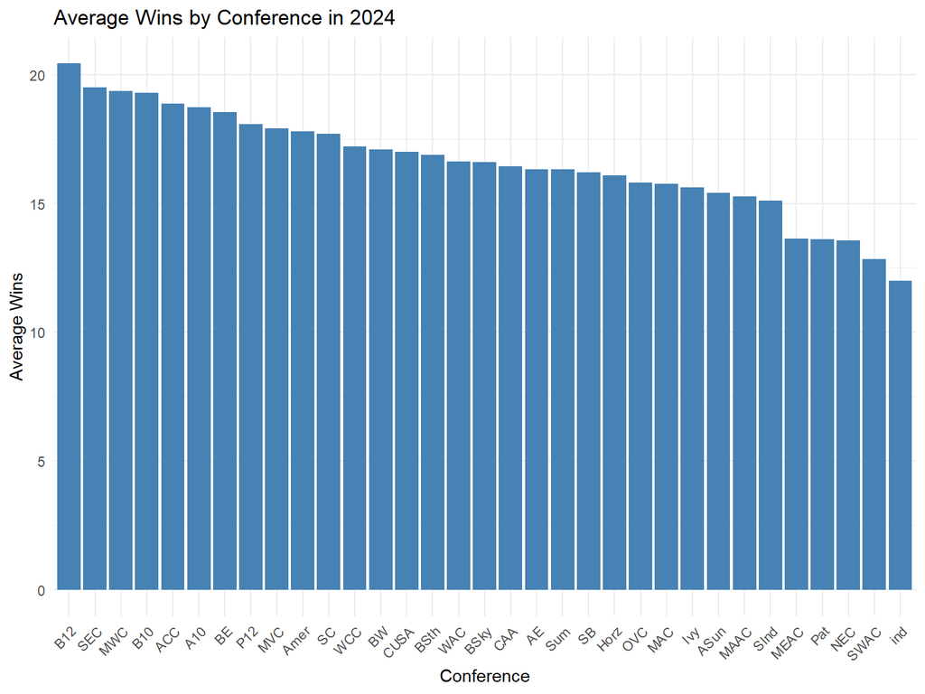

# Impact of Three-Point Shooting on Wins in ACC

How does the percentage of three-pointers made impact the number of games won within the ACC?

–Analyzing this relationship provides insight into whether successful three-point shooting correlates with higher win counts in the ACC.

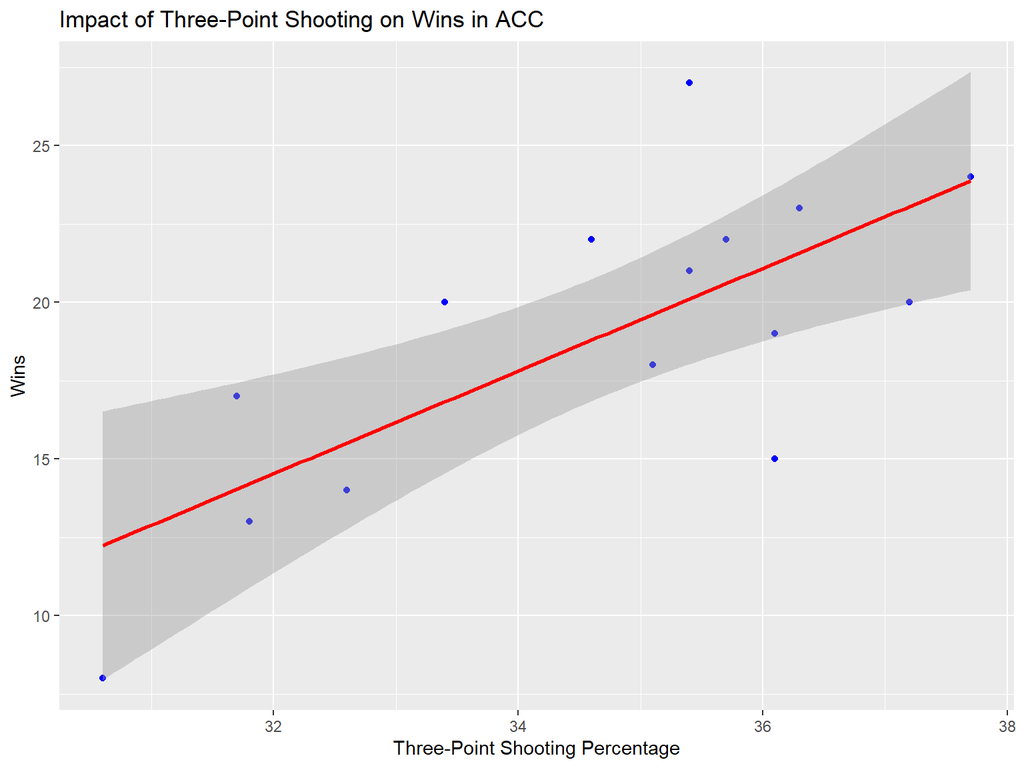

```
##
## Call:
## lm(formula = W ~ X3P_O, data = acc_three)
##
## Residuals:
##    Min     1Q Median     3Q    Max
## -6.250 -1.930  0.127  2.194  6.898
##
## Coefficients:
##             Estimate Std. Error t value Pr(>|t|)
## (Intercept)  -37.941     15.167  -2.502  0.02651 *
## X3P_O          1.640      0.437   3.752  0.00242 **
## ---
## Signif. codes:  0 '***' 0.001 '**' 0.01 '*' 0.05 '.' 0.1 ' ' 1
##
## Residual standard error: 3.5 on 13 degrees of freedom
## Multiple R-squared:  0.5199, Adjusted R-squared:  0.483
## F-statistic: 14.08 on 1 and 13 DF,  p-value: 0.002417
```

# ACC Teams with Above-Average Wins

Which schools in the ACC have won more games than the average for all Division I teams?

–This comparison allows me to identify standout ACC teams and assess their performance relative to the national average.

ACC Teams with Above-Average Wins

| TEAM | W |
| --- | --- |
| North Carolina | 27 |
| Duke | 24 |
| Wake Forest | 20 |
| Clemson | 21 |
| Pittsburgh | 22 |
| Virginia Tech | 18 |
| Virginia | 23 |
| North Carolina St. | 22 |
| Syracuse | 20 |
| Boston College | 19 |
| Florida St. | 17 |

# Adjusted Efficiencies of Top Five Teams

Among the top five teams in 2024 based on win count, is adjusted offensive efficiency or adjusted defensive efficiency higher on average?

–This question examines whether top teams excel more in offensive or defensive play, providing a balanced view of team strengths.

Adjusted Efficiencies of Top Five Teams

| TEAM | W | ADJOE | ADJDE |
| --- | --- | --- | --- |
| Connecticut | 31 | 127.1 | 93.6 |
| James Madison | 31 | 112.0 | 100.4 |
| Houston | 30 | 119.2 | 85.5 |
| McNeese St. | 30 | 111.3 | 101.0 |
| Purdue | 29 | 126.2 | 94.7 |

```
## [1] 119.16
```

```
## [1] 95.04
```

# Average Turnover Rate for Top Five Teams

What is the average number of turnovers for the top five winning teams?

–Turnovers can impact game outcomes, so examining turnover rates among the most successful teams may highlight patterns in ball control.

Average Turnover Rate for Top Five Teams

| avg_turnovers |
| --- |
| 14.8 |

# Average Free Throw Rate for Top 20 Teams

What are the average free throw rates among the top 20 teams? –Free throw performance can play a crucial role in close games, so this analysis explores whether the top teams tend to excel in this area.

Average Free Throw Rate for Top 20 Teams

| avg_free_throw_rate |
| --- |
| 35.65 |

# TRUE OR FALSE: Average Turnover Rate Above 20% for All Teams?

Is the average turnover rate for all teams above 20%?

–This analysis checks if high turnover rates are common across teams or if lower turnover rates are more typical.

```
## $`Average Turnover Rate`
## [1] 17.13729
##
## $`Is Average > 20%`
## [1] FALSE
```

# SIMPLE LINEAR REGRESSION: SEC Offensive and Defensive Efficiencies

How do SEC teams’ offensive and defensive efficiencies compare in 2024 based on a linear regression analysis?

–Using linear regression, this question investigates whether SEC teams show balanced strengths in both offensive and defensive play.

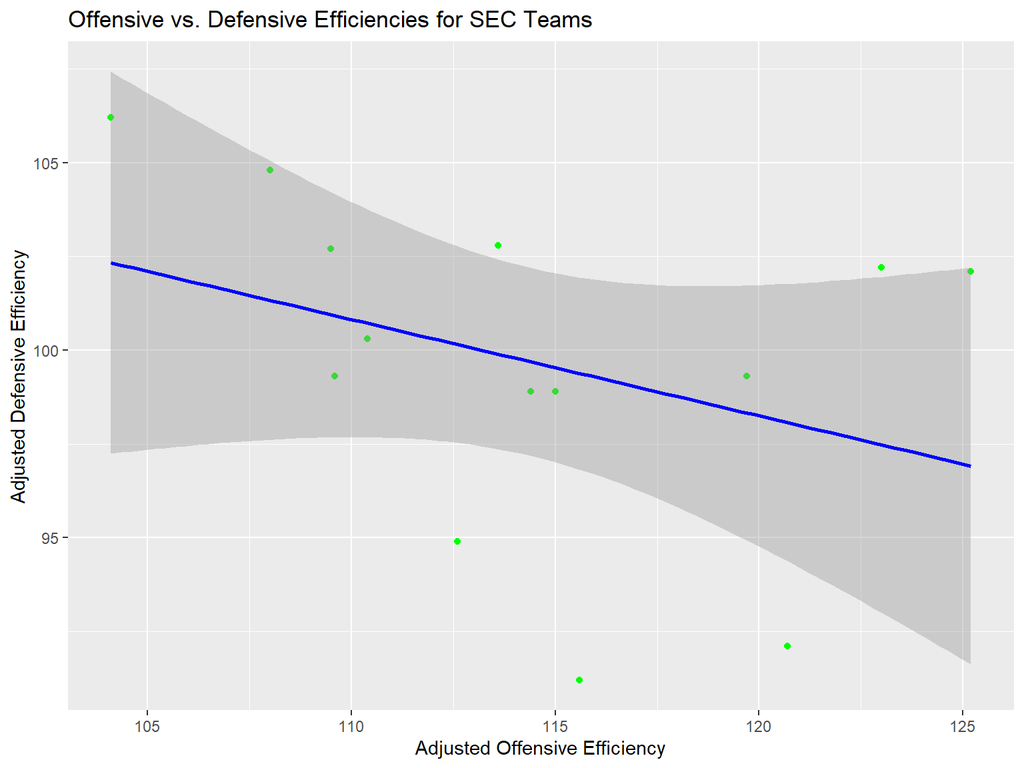

```
##
## Call:
## lm(formula = ADJDE ~ ADJOE, data = sec_teams)
##
## Residuals:
##     Min      1Q  Median      3Q     Max
## -8.1808 -1.4145  0.2779  3.3257  5.1867
##
## Coefficients:
##             Estimate Std. Error t value Pr(>|t|)
## (Intercept) 129.0931    22.6522   5.699 9.93e-05 ***
## ADJOE        -0.2570     0.1978  -1.300    0.218
## ---
## Signif. codes:  0 '***' 0.001 '**' 0.01 '*' 0.05 '.' 0.1 ' ' 1
##
## Residual standard error: 4.307 on 12 degrees of freedom
## Multiple R-squared:  0.1234, Adjusted R-squared:  0.05033
## F-statistic: 1.689 on 1 and 12 DF,  p-value: 0.2182
```